# Introduccion

El análisis de regresión engloba a un conjunto de métodos estadísticos que usamos cuando tanto la variable de respuesta como la la(s) variable(s) predictiva(s) son contínuas y queremos predecir valores de la primera en función de valores observados de las segundas. En esencia, el análisis de regresión consiste en ajustar un modelo a los datos, estimando coeficientes a partir de las observaciones, con el fin de predecir valores de la variable de respuesa a partir de una (regresión simple) o más variables (regresión múltiple) predictivas o explicativas.

El análisis de regresión juega un papel central en la estadística moderna y se usa para:

- identificar a las variables predictivas relacionadas con una variable de respuesta
- describir la forma de la relación entre estas variables y para derivar una función matemática óptima que modele esta relación
- predecir la variable de respuesta a partir de la(s) explicativas o predictoras

[Fuente](https://www.ccg.unam.mx/~vinuesa/R4biosciences/docs/Tema9_regresion.html#introduccion-el-concepto-de-regresion)

## Historia

La primera forma de regresión lineal documentada fue el método de los mínimos cuadrados que fue publicada por **Legendre** en 1805, **Gauss** publicó un trabajo en donde desarrollaba de manera más profunda el método de los mínimos cuadrados,1 y en dónde se incluía una versión del teorema de **Gauss-Márkov**.

El término regresión se utilizó por primera vez en el estudio de variables antropométricas: al comparar la estatura de padres e hijos, donde resultó que los hijos cuyos padres tenían una estatura muy superior al valor medio, tendían a igualarse a este, mientras que aquellos cuyos padres eran muy bajos tendían a reducir su diferencia respecto a la estatura media; es decir, "regresaban" al promedio.2 La constatación empírica de esta propiedad se vio reforzada más tarde con la justificación teórica de ese fenómeno.

El término lineal se emplea para distinguirlo del resto de técnicas de regresión, que emplean modelos basados en cualquier clase de función matemática. Los modelos lineales son una explicación simplificada de la realidad, mucho más ágiles y con un soporte teórico mucho más extenso por parte de la matemática y la estadística.

Pero bien, como se ha dicho, se puede usar el término lineal para distinguir modelos basados en cualquier clase de aplicación.

[figure not shown]

Matematico Gauss

[Fuente](https://es.wikipedia.org/wiki/Regresi%C3%B3n_lineal#Historia)

## Planteamiento del algoritmo matematico

El modelo lineal relaciona la variable dependiente $Y$ con $m$ variables regresoras $X_{j}$ con $j=1,2,..,m$ o cualquier transformación de éstas que generen un hiperplano de parámetros $\beta _{i}$ desconocidos:

$${\begin{aligned} Y&=\beta _{0}+\beta _{1}X_{1}+... +\beta _{m}X_{m}+\varepsilon \\ &=\beta _{0} + \sum_{j=1}^{m} \beta _{j}X_{j}+\varepsilon\end{aligned}}$$

donde $ \epsilon$ es una variable aleatoria que recoge todos aquellos factores de la realidad no controlables u observables y que por tanto se asocian con el azar, y es la que confiere al modelo su carácter estocástico. En el caso más sencillo, con una sola variable explícita, el hiperplano es una recta:

$$ Y=\beta _{0}+\beta _{1}X_{1}+\varepsilon$$

El problema de la regresión consiste en elegir unos valores determinados para los parámetros desconocidos $ \beta _{j}$, de modo que la ecuación quede completamente especificada. Para ello se necesita un conjunto de observaciones o una muestra proveniente de este modelo. En una observación $i-ésima$ $(i=1,2,\dots ,n)$ cualquiera, se registra el comportamiento simultáneo de la variable dependiente y las variables explícitas (las perturbaciones aleatorias se suponen no observables).

$$ y_{i}=\beta _{0}+\sum _{j=1}^{m}\beta _{j}x_{ij}+\varepsilon _{i}$$

Los valores escogidos como estimadores de los parámetros ${\hat {\beta }}_{j}$, son los coeficientes de regresión sin que se pueda garantizar que coincidan con parámetros reales del proceso generador. Por tanto, en

$$Y_{i}=\beta _{0}+\sum _{j=1}^{m}{\hat {\beta }}_{j}X_{ij}+{\hat {\varepsilon }}_{i}$$

Los valores $ {\hat {\varepsilon }}_{i}$ son por su parte estimaciones o errores de la perturbación aleatoria.

### Regresion lineal simple

Este modelo sólo está conformado por dos variables estadísticas llamadas $X$ y $Y$. Para la regresión lineal simple, se asume que $X$ y $Y$ se relacionan mediante la relación funcional:

$$ Y=\beta _{0}+\beta _{1}X+\varepsilon$$

donde $\beta _{0},\beta _{1}\in \mathbb {R}$ son constantes desconocidas llamadas coeficientes de regresión.

#### Estimacion de los parametros

Dado que los parámetros $\beta _{0}$ y $\beta _{1}$ son constantes desconocidas, estas deben estimarse mediante los datos de la muestra, supóngase que se tiene $n$ datos $ \{x_{i},y_{i}\}_{i=1}^{n}$, se estimarán los parámetros utilizando el método de **mínimos cuadrados**.

Se estiman $ \beta _{0}$ y $\beta _{1}$ tal que la suma de los cuadrados de las diferencias entre las observaciones $ y_{i}$ y la recta de regresión sea mínima, esto es, buscamos minimizar la función error cuadrático dada por

$$ S(\beta _{0},\beta _{1})=\sum _{i=1}^{n}(y_{i}-\beta _{0}-\beta _{1}x_{i})^{2}$$

La función de error cuadrático $S(\beta _{0},\beta _{1})$ alcanza un mínimo en el punto $ \left({\hat {\beta }}_{0},{\hat {\beta }}_{1}\right)$ tal que

$$ \left.{\frac {\partial S}{\partial \beta _{0}}}\right|_{{\hat {\beta }}_{0},{\hat {\beta }}_{1}}=\left.{\frac {\partial S}{\partial \beta _{1}}}\right|_{{\hat {\beta }}_{0},{\hat {\beta }}_{1}}=0$$

entonces derivando respecto a $ \beta _{0}$ y $ \beta _{1}$, evaluando en $ {\hat {\beta }}_{0}$ y ${\hat {\beta }}_{1}$ e igualando a cero, obtenemos el siguiente sistema de ecuaciones

$$ {\begin{cases} -2\sum _{i=1}^{n}\left(y_{i}-{\hat {\beta }}_{0}-{\hat {\beta }}_{1}x_{i}\right)=0\\ -2\sum _{i=1}^{n}\left(y_{i}-{\hat {\beta }}_{0}-{\hat {\beta }}_{1}x_{i}\right)x_{i}=0\end{cases}}$$

estas dos ecuaciones son conocidas como ecuaciones normales la solución de dicho sistema de ecuaciones está dada por:

$$ {\begin{aligned}{\hat {\beta }}_{1}&={\frac {\displaystyle \sum _{i=1}^{n}x_{i}y_{i}-n{\bar {x}}{\bar {y}}}{\displaystyle \sum _{i=1}^{n}x_{i}^{2}-{\frac {1}{n}}\left(\sum _{i=1}^{n}x_{i}\right)^{2}}}\\{\hat {\beta }}_{0}&={\frac {\displaystyle \sum _{i=1}^{n}x_{i}^{2}\sum _{i=1}^{n}y_{i}-\sum _{i=1}^{n}x_{i}y_{i}\sum _{i=1}^{n}x_{i}}{\displaystyle n\sum _{i=1}^{n}x_{i}^{2}-\left(\sum _{i=1}^{n}x_{i}\right)^{2}}}={\bar {y}}-{\hat {\beta }}_{1}{\bar {x}}\end{aligned}}$$

La interpretación del parámetro medio $\beta _{1}$ es que un incremento en Xi de una unidad, Yi incrementará en $\beta _{1}$. Luego el modelo ajustado de regresión lineal simple es

$${\hat {y}}={\hat {\beta }}_{0}+{\hat {\beta }}_{1}x$$

[Fuente](https://es.wikipedia.org/wiki/Regresi%C3%B3n_lineal#Historia)

## Ejemplo Regresion Simple (Japan Earthquake)

[Fuente Datos Kaggle](https://www.kaggle.com/aerodinamicc/earthquakes-in-japan)

```python
import numpy as np
import pandas as pd
import seaborn as sb
import matplotlib.pyplot as plt
from sklearn import linear_model
from sklearn.metrics import mean_squared_error, r2_score

# Librerias para graficar en 3 dimensiones
%matplotlib inline
from mpl_toolkits.mplot3d import Axes3D
from matplotlib import cm
plt.rcParams['figure.figsize'] = (16, 9)
plt.style.use('ggplot')
```

```python
data= pd.read_csv("C:/Users/H216966/OneDrive - Halliburton/Documents/Maestria Estadistica/Semestre 2021-1/Ciencia de datos/Datos/Japan earthquakes 2001 - 2018.csv")
data.shape
```

```
(14092, 22)
```

```python
data.head()
```

|  | time | latitude | longitude | depth | mag | magType | nst | gap | dmin | rms | ... | updated | place | type | horizontalError | depthError | magError | magNst | status | locationSource | magSource |
| --- | --- | --- | --- | --- | --- | --- | --- | --- | --- | --- | --- | --- | --- | --- | --- | --- | --- | --- | --- | --- | --- |
| 0 | 2018-11-27T14:34:20.900Z | 48.3780 | 154.9620 | 35.00 | 4.9 | mb | NaN | 92.0 | 5.044 | 0.63 | ... | 2018-11-27T16:06:33.040Z | 269km SSW of Severo-Kuril'sk, Russia | earthquake | 7.6 | 1.7 | 0.036 | 248.0 | reviewed | us | us |
| 1 | 2018-11-26T23:33:50.630Z | 36.0733 | 139.7830 | 48.82 | 4.8 | mww | NaN | 113.0 | 1.359 | 1.13 | ... | 2018-11-27T16:44:22.223Z | 3km SSW of Sakai, Japan | earthquake | 6.0 | 6.1 | 0.071 | 19.0 | reviewed | us | us |
| 2 | 2018-11-26T13:04:02.250Z | 38.8576 | 141.8384 | 50.56 | 4.5 | mb | NaN | 145.0 | 1.286 | 0.84 | ... | 2018-11-26T23:52:21.074Z | 26km SSE of Ofunato, Japan | earthquake | 8.4 | 9.5 | 0.156 | 12.0 | reviewed | us | us |
| 3 | 2018-11-26T05:20:16.440Z | 50.0727 | 156.1420 | 66.34 | 4.6 | mb | NaN | 128.0 | 3.191 | 0.62 | ... | 2018-11-26T08:13:58.040Z | 67km S of Severo-Kuril'sk, Russia | earthquake | 9.7 | 7.8 | 0.045 | 151.0 | reviewed | us | us |
| 4 | 2018-11-25T09:19:05.010Z | 33.9500 | 134.4942 | 38.19 | 4.6 | mb | NaN | 104.0 | 0.558 | 0.61 | ... | 2018-11-25T23:24:52.615Z | 9km SW of Komatsushima, Japan | earthquake | 3.4 | 10.1 | 0.132 | 17.0 | reviewed | us | us |

5 rows × 22 columns

```python
data.describe()
```

|  | latitude | longitude | depth | mag | nst | gap | dmin | rms | horizontalError | depthError | magError | magNst |
| --- | --- | --- | --- | --- | --- | --- | --- | --- | --- | --- | --- | --- |
| count | 14092.000000 | 14092.000000 | 14092.000000 | 14092.000000 | 10483.000000 | 13310.000000 | 3607.000000 | 14014.000000 | 2800.000000 | 9040.000000 | 3431.000000 | 11048.000000 |
| mean | 37.410294 | 142.980441 | 51.364838 | 4.817045 | 117.352094 | 104.272149 | 2.359796 | 0.876561 | 7.288607 | 7.822920 | 0.095182 | 48.590695 |
| std | 6.605873 | 6.552510 | 76.603810 | 0.378618 | 123.273889 | 37.893474 | 1.658681 | 0.203787 | 2.263028 | 5.861948 | 0.060710 | 70.233727 |
| min | 23.532900 | 124.293000 | 0.000000 | 4.500000 | 5.000000 | 8.000000 | 0.038000 | 0.120000 | 1.400000 | 0.000000 | 0.019000 | 1.000000 |
| 25% | 33.147675 | 141.071000 | 14.400000 | 4.600000 | 36.000000 | 78.000000 | 1.109000 | 0.740000 | 5.800000 | 4.400000 | 0.054000 | 9.000000 |
| 50% | 37.357000 | 142.452100 | 35.000000 | 4.700000 | 69.000000 | 112.700000 | 1.979000 | 0.850000 | 7.100000 | 6.200000 | 0.079000 | 23.000000 |
| 75% | 42.271325 | 144.432000 | 50.372500 | 4.900000 | 153.000000 | 130.900000 | 3.122500 | 0.990000 | 8.500000 | 9.600000 | 0.118000 | 57.000000 |
| max | 50.816100 | 158.818000 | 683.360000 | 9.100000 | 929.000000 | 306.600000 | 18.781000 | 1.880000 | 25.600000 | 70.700000 | 0.555000 | 941.000000 |

```python
data.dtypes
```

```
time                object
latitude           float64
longitude          float64
depth              float64
mag                float64
magType             object
nst                float64
gap                float64
dmin               float64
rms                float64
net                 object
id                  object
updated             object
place               object
type                object
horizontalError    float64
depthError         float64
magError           float64
magNst             float64
status              object
locationSource      object
magSource           object
dtype: object
```

```python
pd.index(data)
```

[output not shown]

```python
pd.isnull(data['depth'])
```

```
0        False
1        False
2        False
3        False
4        False
         ...
14087    False
14088    False
14089    False
14090    False
14091    False
Name: depth, Length: 14092, dtype: bool
```

```python
datareg=data.iloc[:,3:5]# coge todas las filas de las columanas 3,4
```

```
array([[<AxesSubplot:title={'center':'depth'}>,
        <AxesSubplot:title={'center':'mag'}>]], dtype=object)
```

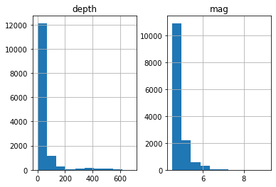

```python
datareg.hist()
```

```python
#filtered_data = datareg[(datareg['depth'] <= 70) & (datareg['mag'] <= 5)]
```

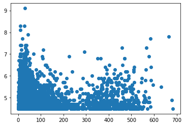

```python
#f1 = filtered_data['depth'].values
#f2 = filtered_data['mag'].values

plt.scatter(datareg['depth'],datareg['mag'])
plt.show()
```

```python
# Asignamos nuestra variable de entrada X para entrenamiento y las etiquetas Y.
#dataX =datareg['depth'].values
X_train = datareg['depth'].values
y_train = datareg['mag'].values

# Creamos el objeto de Regresión Linear
regr = linear_model.LinearRegression()

# Entrenamos nuestro modelo
regr.fit(X_train.reshape(-1,1), y_train)

# Hacemos las predicciones que en definitiva una línea (en este caso, al ser 2D)
y_pred = regr.predict(X_train.reshape(-1,1))

# Veamos los coeficienetes obtenidos, En nuestro caso, serán la Tangente
print('Coefficients: \n', regr.coef_)
# Este es el valor donde corta el eje Y (en X=0)
print('Independent term: \n', regr.intercept_)
# Error Cuadrado Medio
print("Mean squared error: %.2f" % mean_squared_error(y_train, y_pred))
# Puntaje de Varianza. El mejor puntaje es un 1.0
print('Variance score: %.2f' % r2_score(y_train, y_pred))
```

```
Coefficients:
 [0.00028187]
Independent term:
 4.802566814200258
Mean squared error: 0.14
Variance score: 0.00
```

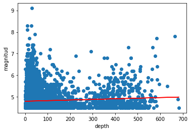

```python
plt.scatter(datareg['depth'],datareg['mag'])
plt.plot(datareg['depth'],y_pred,'r')
plt.xlabel('depth')
plt.ylabel('magnitud')
```

## Ejemplo Regresion Multiple (Heart Attack possibility)

[Fuente Datos Kaggle](https://www.kaggle.com/nareshbhat/health-care-data-set-on-heart-attack-possibility)

```python
data2= pd.read_csv("C:/Users/H216966/OneDrive - Halliburton/Documents/Maestria Estadistica/Semestre 2021-1/Ciencia de datos/Datos/heart.csv")
data2.shape
```

```
(303, 14)
```

```python
data2.head()
```

|  | age | sex | cp | trestbps | chol | fbs | restecg | thalach | exang | oldpeak | slope | ca | thal | target |
| --- | --- | --- | --- | --- | --- | --- | --- | --- | --- | --- | --- | --- | --- | --- |
| 0 | 63 | 1 | 3 | 145 | 233 | 1 | 0 | 150 | 0 | 2.3 | 0 | 0 | 1 | 1 |
| 1 | 37 | 1 | 2 | 130 | 250 | 0 | 1 | 187 | 0 | 3.5 | 0 | 0 | 2 | 1 |
| 2 | 41 | 0 | 1 | 130 | 204 | 0 | 0 | 172 | 0 | 1.4 | 2 | 0 | 2 | 1 |
| 3 | 56 | 1 | 1 | 120 | 236 | 0 | 1 | 178 | 0 | 0.8 | 2 | 0 | 2 | 1 |
| 4 | 57 | 0 | 0 | 120 | 354 | 0 | 1 | 163 | 1 | 0.6 | 2 | 0 | 2 | 1 |

```python
data2.dtypes
```

```
age           int64
sex           int64
cp            int64
trestbps      int64
chol          int64
fbs           int64
restecg       int64
thalach       int64
exang         int64
oldpeak     float64
slope         int64
ca            int64
thal          int64
target        int64
dtype: object
```

```python
datareg2=data2.iloc[:,[0,3,4,7]]# coge todas las filas de las columanas 3,4
```

```python
datareg2.head()
```

|  | age | trestbps | chol | thalach |
| --- | --- | --- | --- | --- |
| 0 | 63 | 145 | 233 | 150 |
| 1 | 37 | 130 | 250 | 187 |
| 2 | 41 | 130 | 204 | 172 |
| 3 | 56 | 120 | 236 | 178 |
| 4 | 57 | 120 | 354 | 163 |

```
array([[<AxesSubplot:title={'center':'age'}>,
        <AxesSubplot:title={'center':'trestbps'}>],
       [<AxesSubplot:title={'center':'chol'}>,
        <AxesSubplot:title={'center':'thalach'}>]], dtype=object)
```

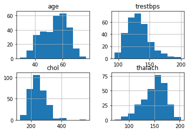

```python
datareg2.hist()
```

```
array([[<AxesSubplot:xlabel='age', ylabel='age'>,
        <AxesSubplot:xlabel='trestbps', ylabel='age'>,
        <AxesSubplot:xlabel='chol', ylabel='age'>,
        <AxesSubplot:xlabel='thalach', ylabel='age'>],
       [<AxesSubplot:xlabel='age', ylabel='trestbps'>,
        <AxesSubplot:xlabel='trestbps', ylabel='trestbps'>,
        <AxesSubplot:xlabel='chol', ylabel='trestbps'>,
        <AxesSubplot:xlabel='thalach', ylabel='trestbps'>],
       [<AxesSubplot:xlabel='age', ylabel='chol'>,
        <AxesSubplot:xlabel='trestbps', ylabel='chol'>,
        <AxesSubplot:xlabel='chol', ylabel='chol'>,
        <AxesSubplot:xlabel='thalach', ylabel='chol'>],
       [<AxesSubplot:xlabel='age', ylabel='thalach'>,
        <AxesSubplot:xlabel='trestbps', ylabel='thalach'>,
        <AxesSubplot:xlabel='chol', ylabel='thalach'>,
        <AxesSubplot:xlabel='thalach', ylabel='thalach'>]], dtype=object)
```

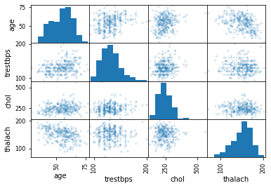

```python
pd.plotting.scatter_matrix(datareg2, alpha=0.2)
```

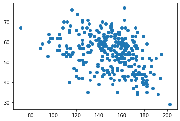

```python
plt.scatter(datareg2['thalach'],datareg2['age'])
plt.show()
```

```python
suma = (datareg2["trestbps"] + datareg2['chol'])
dataX2 =  pd.DataFrame()
dataX2["thalach"] = datareg2["thalach"]
dataX2["suma"] = suma
XY_train = np.array(dataX2)
z_train = datareg2['age'].values


# Creamos un nuevo objeto de Regresión Lineal
regr2 = linear_model.LinearRegression()

# Entrenamos el modelo, esta vez, con 2 dimensiones
# obtendremos 2 coeficientes, para graficar un plano
regr2.fit(XY_train, z_train)

# Hacemos la predicción con la que tendremos puntos sobre el plano hallado
z_pred = regr2.predict(XY_train)

# Los coeficientes
print('Coefficients: \n', regr2.coef_)
# Error cuadrático medio
print("Mean squared error: %.2f" % mean_squared_error(z_train, z_pred))
# Evaluamos el puntaje de varianza (siendo 1.0 el mejor posible)
print('Variance score: %.2f' % r2_score(z_train, z_pred))
```

```
Coefficients:
 [-0.1554774   0.04360843]
Mean squared error: 63.06
Variance score: 0.23
```

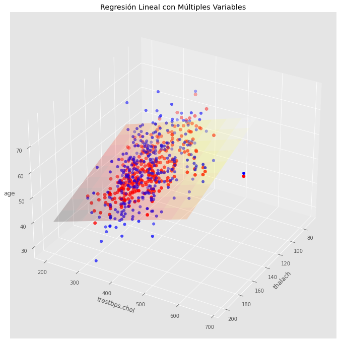

```python
### Graficacion 3D
fig = plt.figure()
ax = Axes3D(fig)

# Creamos una malla, sobre la cual graficaremos el plano
xx, yy = np.meshgrid(np.linspace(100, 200, num=10), np.linspace(200, 600, num=10))

# calculamos los valores del plano para los puntos x e y
nuevoX = (regr2.coef_[0] * xx)
nuevoY = (regr2.coef_[1] * yy)

# calculamos los correspondientes valores para z. Debemos sumar el punto de intercepción
z = (nuevoX + nuevoY + regr2.intercept_)

# Graficamos el plano
ax.plot_surface(xx, yy, z, alpha=0.2, cmap='hot')

# Graficamos en azul los puntos en 3D
ax.scatter(XY_train[:, 0], XY_train[:, 1], z_train, c='blue',s=30)

# Graficamos en rojo, los puntos que se predijeron
ax.scatter(XY_train[:, 0], XY_train[:, 1], z_pred, c='red',s=40)

# con esto situamos la "camara" con la que visualizamos
ax.view_init(elev=30., azim=30)

ax.set_xlabel('thalach')
ax.set_ylabel('trestbps,chol')
ax.set_zlabel('age')
ax.set_title('Regresión Lineal con Múltiples Variables')
```

[Fuente Codigo para la regresion simple y multiple](https://www.aprendemachinelearning.com/regresion-lineal-en-espanol-con-python/)